# STATUN2102: Visualization in Python

Ben Goodrich

## Homework

- Homework due Tuesday night
- Just upload the PDF, not the RMarkdown file
- Replace the entire YAML block with

```
title: "UNSTAT2102: Homework 4"
author: "Due Tuesday November 17 by 11:59PM"
output:
  pdf_document:
    number_sections: true
    pandoc_args: --listings
header-includes:
  - \lstset{breaklines=true, basicstyle=\ttfamily\small}
```

## Quiz

- Will review for 30 minutes at the start of Wednesday
- Followed by a 45 minute quiz on Python only
- Quiz will utilize Proctorio screen-recording
- Get everything off your screen that you do not want recorded
- In a recently released version of Chrome, make sure you are on Columbia WiFi and go to `Canvas -> Quizzes -> Proctorio Diagonstic` to install the extension and make sure it is working.

## The plotnine Library

https://plotnine.org/ for Python implements the same “Grammar of Graphics” as in the ggplot2 R package, so you can utilize it in essentially the same way. See also https://jeroenjanssens.com/plotnine/ .

```python
import plotnine as p9
import pandas as pd

tips = pd.read_csv("https://tinyurl.com/5206tips")
# This is Python!
p9.ggplot(tips) + p9.geom_point(mapping=p9.aes(x="total_bill", y="tip"))
```

Note that variable names need to be put inside quotation marks in Python, whereas in R they do not

## Plot from Previous Slide

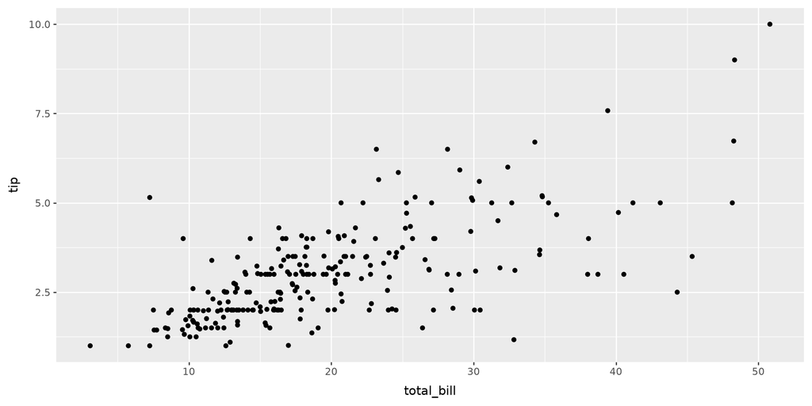

## Practice

```python
import pandas as pd
fatalities = pd.read_csv("nhtsa2010fars.csv") # Canvas -> Files
```

How can we visualize the relationship between drinking and highway fatalities using plotnine?

## Answer: Recoding

How might we construct a plot to illustrate how deaths in car accidents are related to drunk driving? First, we create and / or recode some variables:

```python
fatalities['DRUNK'] = fatalities.DRUNK_DR > 0
mapping = {
    1: 6, # Sunday
    2: 0, # Monday
    3: 1, # Tuesday
    4: 2, # Wednesday
    5: 3, # Thursday
    6: 4, # Friday
    7: 5  # Saturday
}
fatalities['DAY_WEEK'] = fatalities.DAY_WEEK.replace(mapping)
fatalities['DAY_WEEK'] = pd.Categorical.from_codes(fatalities.DAY_WEEK,
  categories = ['Mon', 'Tue', 'Wed', 'Thu', 'Fri', 'Sat', 'Sun'])
fatalities.loc[fatalities.HOUR > 24, 'HOUR'] = None
fatalities['TIME'] = fatalities.HOUR + fatalities.MINUTE / 60
```

## Answer: Plot

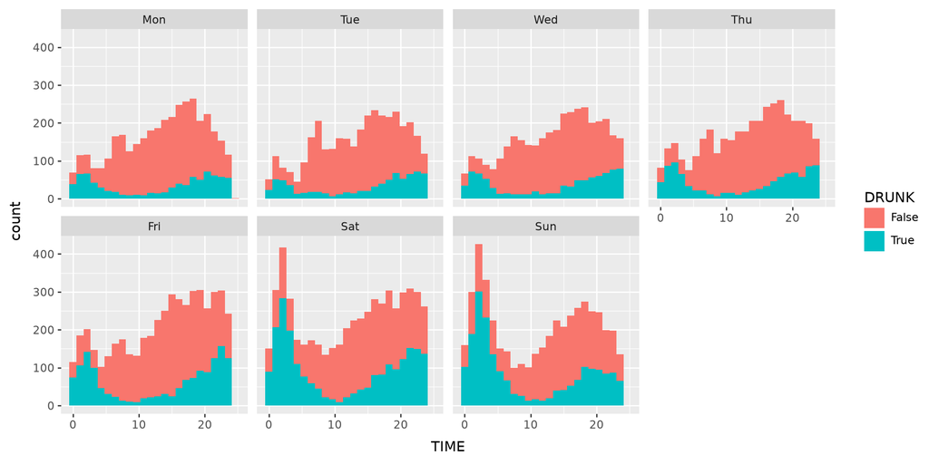

```python
gg = p9.ggplot(fatalities) + p9.facet_wrap("DAY_WEEK", nrow = 2)
gg + p9.geom_histogram(mapping = p9.aes("TIME", fill = "DRUNK"), bins = 24)
```

## Visualization in Python

Although plotnine is good, it is not utilized much by Python users. The two main packages for making decent Python graphics are:

- `matplotlib.pyplot` often shortened as `plt` in code, which is sort of like “base” graphics in R
- `seaborn` often shortened as `sns` in code

Overall, `seaborn` creates modern looking visuals but `matplotlib.pyplot` controls some important internals between graphics. For example, plotting 2 subplots side by side requires `plt` to coordinate the two plots but `sns` will create beautiful looking plots without much specification.

## Tutorials

The [`seaborn` tutorial](https://seaborn.pydata.org/tutorial.html) is quite thorough. I recommend reading the “Data structures accepted by seaborn” before reading the “Overview of seaborn plotting functions”. To examine plots:

- if you want to do so interactively, then you need to call `plt.show()` at the end of your code. This often launches a separate program that will show the graphic. This will hold-up your REPL session until you close the program (i.e. you cannot type in new commands to the REPL) so be careful.
- if you want to save the plots, then I recommend `plt.savefig('MYPLOTNAME.png')`. This will save it to the current working directory byt will overwrite any plot that shares the same name.

## Example Code

The example below is an over-simplified version from the [seaborn tutorial on function overview](https://seaborn.pydata.org/tutorial/function_overview.html).

```python
import matplotlib.pyplot as plt
import seaborn as sns

penguins = sns.load_dataset("penguins")
f, axs = plt.subplots(1, 2)  # 1 row and 2 columns for the subplots
sns.scatterplot(data=penguins,
                x="flipper_length_mm",
                y="bill_length_mm",
                hue="species",
                ax=axs[0]) # This places this graph on the first subplot
sns.histplot(data=penguins,
             x="species",
             hue="species",
             legend=False, # This is supresses bc the first subplot has it
             ax=axs[1])    # This places this graph on the second subplot
plt.savefig('test_seaborn.png') # create a file at your working directory
plt.close() # best practice
```

## Plots with Pandas

To create good graphics, most people think about what they want to plot, look up examples online that shows a similar graphic, then tweak the code until the graphic looks right.

```python
penguins.bill_depth_mm.plot.density();
```

[output not shown]

Practice making more plots from P4DA using `penguins` data.

```python
import numpy as np

df = pd.DataFrame(np.random.standard_normal((10, 4)).cumsum(0),
                  columns=["A", "B", "C", "D"],
                  index=np.arange(0, 100, 10))
plt.style.use('grayscale')
df.plot();
```

[output not shown]